# Tutorial Outline

1. Introduction
2. Accessing the Data using SRA-Toolkit
3. Quality control using scythe/sickle
4. Aligning Reads to a Genome using hisat2
   1. Building an Index
   2. Aligning the reads using HISAT2
5. Generating Total Read Counts from Alignment using htseq-count
   1. Assignemnt 3 Activity 1
6. Differential expression with counts and edgeR
   1. Using EdgeR
   2. Normalization
   3. Comparision between groups
   4. Common plots for differential expression analysis
7. Integrating the DE Results with the Annotation Results
8. Assignment 3 Activity 2

# 1. Introduction

This exercise will guide you through the RNAseq analysis using Illumina sequence data and identify genes that display differences in expression between experimental treatments (*i.e.* Differentially expressed genes. Below is the overview of the steps that we need to complete inorder to obtain a list of differentially expressed genes.

[figure not shown]

Liver mRNA profiles from large yellow croaker (*Larimichthys crocea*) species are sampled during various conditions namely, control group (LB2A), thermal stress group (LC2A), cold stress group (LA2A) and 21-day fasting group (LF1A) were generated by RNA-seq, using Illumina HiSeq 2000. Below is a picture of *Larimichthys crocea* to give you an idea of the organism that we will be working with throughout the exercise.

[figure not shown]

# 2. Accessing the Data using SRA-Toolkit

We will be downloading our data from the sequence-read-archives (SRA), a comprehensive collection of sequenced genetic data submitted to the NCBI by experimenters. The beauty of the SRA is the ease with which genetic data becomes accessible to any scientist with an internet connection, available for download in a variety of formats. Each run in the SRA has a unique identifier. The run may be downloaded using a module of software called the "sratoolkit" and its unique identifier. There are a variety of commands in the sratoolkit, which I invite you to investigate for yourself at https://www.ncbi.nlm.nih.gov/books/NBK158900/. The data may be accessed at the following web page: https://trace.ncbi.nlm.nih.gov/Traces/sra/?study=SRP057063

```
LF1A : SRR1964648, SRR1964649
LA2A : SRR1964646, SRR1964647
LB2A : SRR1964642, SRR1964643
LC2A : SRR1964644, SRR1964645
```

We can download the SRA data using a parallel version SRA-Toolkit that allows for multiple threads (CPU) using the following bash code but this step has already been completed using `liver_dump.sh` because of time constraints:

```
#!/bin/bash

SRA="SRR1964648
     SRR1964649
     SRR1964646
     SRR1964647
     SRR1964642
     SRR1964643
     SRR1964644
     SRR1964645"

for i in $SRA
do
parallel-fastq-dump --sra-id $i --threads 4 --outdir /home/WWU/BIOL497R/data/RNAseq/ --split-files --gzip
done
```

Data is located in:

```
/home/WWU/BIOL497R/data/RNAseq/
```

Lets have a look at athe contents of one of the fastq-files:

```python
%%bash

head -n 8 /home/WWU/BIOL497R/data/RNAseq/SRR1964648_1.fastq
```

[output not shown]

# 3. Quality control using scythe/sickle

In this section, we will do the quality control processing of the RNAseq libraries. This incorperates content that we learned in **Ex3_read_processing**.

Briefly, `scythe` removes adapter contamination from the Illumina sequencing technology and `sickle` performs the quality trimming. Below are the usage examples for each program.

Scythe:

```
Usage: scythe -a adapter_file.fasta sequence_file.fastq
Trim 3'-end adapter contaminants off sequence files. If no output file
is specified, scythe will use stdout.

Options:
  -p, --prior       prior (default: 0.300)
  -q, --quality-type    quality type, either illumina, solexa, or sanger (default: sanger)
  -m, --matches-file    matches file (default: no output)
  -o, --output-file output trimmed sequences file (default: stdout)
  -t, --tag     add a tag to the header indicating Scythe cut a sequence (default: off)
  -n, --min-match   smallest contaminant to consider (default: 5)
  -M, --min-keep    filter sequnces less than or equal to this length (default: 35)
  --quiet       don't output statistics about trimming to stdout (default: off)
  --help        display this help and exit
  --version     output version information and exit
```

Sickle and since we have single end sequences, typing `sickle se` will give the single-end-read options:

```
Usage: sickle se [options] -f  -t  -o

Options:
-f, --fastq-file, Input fastq file (required)
-t, --qual-type, Type of quality values (solexa (CASAVA < 1.3), illumina (CASAVA 1.3 to 1.7), sanger (which is CASAVA >= 1.8)) (required)
-o, --output-file, Output trimmed fastq file (required)
-q, --qual-threshold, Threshold for trimming based on average quality in a window. Default 20.
-l, --length-threshold, Threshold to keep a read based on length after trimming. Default 20.
-x, --no-fiveprime, Don't do five prime trimming.
-n, --trunc-n, Truncate sequences at position of first N.
-g, --gzip-output, Output gzipped files.
--quiet, Don't print out any trimming  Information
--help, display this help and exit
--version, output version  Information and exit
```

The quality may be any score from 0 to 40. The default of 20 is much too low for a robust analysis. We want to select only reads with a quality of 30 or better. Additionally, the Illumina sequencing technology used in this experiment generated read lengths of 50bp. Again, we see that a default of 20 is much too low for analysis confidence. We want to select only reads whose lengths exceed 36bp. Lastly, we must know the scoring type. While the quality type is not listed on the SRA pages, most SRA reads use the "sanger" quality type. Unless explicitly stated, try running sickle using the sanger qualities. If an error is returned, try illumina. If another error is returned, lastly try solexa.  
Let's put all of this together for our scythe/sickle processing using our downloaded fastq files:

```
DATA="/home/WWU/BIOL497R/data/RNAseq"
ADAPTERS="/home/WWU/BIOL497R/notebooks/Ex3_read_processing/adapters.fa"
SRA="SRR1964648_1
     SRR1964649_1
     SRR1964646_1
     SRR1964647_1
     SRR1964642_1
     SRR1964643_1
     SRR1964644_1
     SRR1964645_1"

for i in $SRA
do

#save stdout messages to .out for each library
scythe -a $ADAPTERS --quiet -o $DATA/quality_control/$i.scythe.fastq $DATA/$i.fastq 1 &> quality_control/$i.out

sickle se -f $DATA/quality_control/$i.scythe.fastq -t sanger -q 30 -l 36 -o $DATA/quality_control/$i.scythe.sickle.fastq >> quality_control/$i.out

done
```

Following the scythe/sickle run the results can be found in the **$DATA/quality_control** folder. Examine the .out files generated during the run. It will provide a summary of the quality control process. The resulting file structure will look as follows:

```
$DATA/quality_control/
├── SRR1964642_1.out
├── SRR1964642_1.scythe.fastq
├── SRR1964642_1.scythe.sickle.fastq
.
.
.
├── SRR1964649_1.out
├── SRR1964649_1.scythe.fastq
└── SRR1964649_1.scythe.sickle.fastq
```

Lastly, we can conduct a before and after QC analysis using fastQC.

```
DATA="/home/WWU/BIOL497R/data/RNAseq"
SRA="SRR1964648_1
     SRR1964649_1
     SRR1964646_1
     SRR1964647_1
     SRR1964642_1
     SRR1964643_1
     SRR1964644_1
     SRR1964645_1"

for i in $SRA
do

#before
fastqc --outdir $DATA/before $DATA/$i.fastq -t 4

#after
fastqc --outdir $DATA/after $DATA/quality_control/$i.scythe.sickle.fastq -t 4

done
```

This will produce the html files with the quality reports and the file strucutre in side the folder fastqc will look like:

```
$DATA/fastqc/
├── after
│   ├── SRR1964642_1.scythe.sickle_fastqc.html
│   ├── SRR1964642_1.scythe.sickle_fastqc.zip
│   ├── ...
│   ├── ...
│   ├── SRR1964649_1.scythe.sickle_fastqc.html
│   └── SRR1964649_1.scythe.sickle_fastqc.zip
├── before
│   ├── SRR1964642_1_fastqc.html
│   ├── SRR1964642_1_fastqc.zip
│   ├── ...
│   ├── ...
│   ├── SRR1964649_1_fastqc.html
│   └── SRR1964649_1_fastqc.zip
```

# 4. Aligning Reads to a Genome using hisat2

## A. Building an Index:

HISAT2 is a fast and sensitive aligner for mapping next generation sequencing reads against a reference genome. In order to map the reads to a reference genome, first we must download the reference genome! Then we must make an index file. We will be downloading the reference genome (https://www.ncbi.nlm.nih.gov/genome/12197) from the ncbi database, using the wget command and rename the files to L_crocea.

```python
%%bash

wget -q ftp://ftp.ncbi.nlm.nih.gov/genomes/all/GCF/000/972/845/GCF_000972845.1_L_crocea_1.0/GCF_000972845.1_L_crocea_1.0_genomic.fna.gz -O L_crocea.fna.gz

gunzip L_crocea.fna.gz

wget -q ftp://ftp.ncbi.nlm.nih.gov/genomes/all/GCF/000/972/845/GCF_000972845.1_L_crocea_1.0/GCF_000972845.1_L_crocea_1.0_genomic.gff.gz -O L_crocea.gff.gz

gunzip L_crocea.gff.gz
```

We will use the **`hisat2-build`** option to make a HISAT index file for the genome. It will create a set of files with the suffix .ht2, these files together build the index. What is an index and why is it helpful? Genome indexing is the same as indexing a tome, like an encyclopedia. It is much easier to locate information in the vastness of an encyclopedia when you consult the index, which is ordered in an easily navigatable way with pointers to the location of the information you seek within the encylopedia. Genome indexing is thus the structuring of a genome such that it is ordered in an easily navigatable way with pointers to where we can find whichever gene is being aligned. The genome index along with the quality trimmed fasta files are all you need to align the reads to the reference genome.

```
HISAT2 version 2.1.0 by Daehwan Kim (infphilo@gmail.com, http://www.ccb.jhu.edu/people/infphilo)
Usage: hisat2-build [options]* <reference_in> <ht2_index_base>
    reference_in            comma-separated list of files with ref sequences
    hisat2_index_base       write ht2 data to files with this dir/basename
Options:
    -c                      reference sequences given on cmd line (as
                            <reference_in>)
    --large-index           force generated index to be 'large', even if ref
                            has fewer than 4 billion nucleotides
    -a/--noauto             disable automatic -p/--bmax/--dcv memory-fitting
    -p                      number of threads
```

```python
%%bash

hisat2-build -p 4 L_crocea.fna  L_crocea
```

After running the command, the following files will be generated as part of the index. To refer to the index for mapping the reads in the next step, you will use the file prefix, which in this case is: `L_crocea`

```
RNAseq/
├── L_crocea.gff
├── L_crocea.fna
├── L_crocea.1.ht2
├── L_crocea.2.ht2
├── L_crocea.3.ht2
├── L_crocea.4.ht2
├── L_crocea.5.ht2
├── L_crocea.6.ht2
├── L_crocea.7.ht2
└── L_crocea.8.ht2
```

## B. Aligning the reads using HISAT2:

Once we have created the index, the next step is to align the reads with HISAT2 using the index we created. The program will give the output in SAM format. We will not delve into the intricacies of the SAM format here, but it is recommended to peruse https://en.wikipedia.org/wiki/SAM_(file_format) again to garner a greater understanding. We align our reads with the following code.

**Usage:**

```
Usage: hisat2 [options]* -x <ht2-idx>  [-S <sam>]
-x <ht2-idx>        path to the Index-filename-prefix (minus trailing .X.ht2)

Options:
-q                  query input files are FASTQ .fq/.fastq (default)
-p                  number threads
--dta               reports alignments tailored for transcript assemblers
```

**Command for aligning the reads using hisat:**

```python
%%bash

DATA="/home/WWU/BIOL497R/data/RNAseq"

mkdir sam
hisat2 -p 4 --dta -x L_crocea -q $DATA/quality_control/SRR1964648_1.scythe.sickle.fastq -S sam/SRR1964648.sam
```

When HISAT2 completes its run, it will summarize each of it’s alignments, and it is printed to the window as standard error message. Below is what one of those meassages look like:

```
25754901 reads; of these:
  25754901 (100.00%) were unpaired; of these:
    1793224 (6.96%) aligned 0 times
    21247602 (82.50%) aligned exactly 1 time
    2714075 (10.54%) aligned >1 times
93.04% overall alignment rate
```

Let's have a look at the SAM file:

```
@HD VN:1.0 SO:unsorted
@SQ SN:NW_017607850.1 LN:6737
@SQ SN:NW_017607851.1 LN:5396
@SQ SN:NW_017607852.1 LN:5050
@SQ SN:NW_017607853.1 LN:5873
@SQ SN:NW_017607854.1 LN:5692
@SQ SN:NW_017607855.1 LN:11509
@SQ SN:NW_017607856.1 LN:12722
@SQ SN:NW_017607857.1 LN:42555
@SQ SN:NW_017607858.1 LN:11917
```

After reading up on the SAM file format, you know that the "@" sign means that we are in the headings section, not the alignment section! The sam file is quite large so there is little purpose in scrolling to find the alignments section (the file is also much too large for using the "grep" command to locate the alignment section). Because of the density of the sam file, it is compressed to binary to create a more easily tractable file for manipulation by future programs.

**Usage:**

```
Usage: samtools [command] [options] in.sam
Command:
view     prints all alignments in the specified input alignment file (in SAM, BAM, or CRAM format) to standard output in SAM format

Options:
-h      Include the header in the output
-S      Indicate the input was in SAM format
-u      Output uncompressed BAM. This option saves time spent on compression/decompression and is thus preferred when the output is piped to another samtools command
-@      Number of processors

Usage: samtools [command] [-o out.bam]
Command:
sort    Sort alignments by leftmost coordinates

-o      Write the final sorted output to FILE, rather than to standard output.
```

The sam file then need to be converted in to bam format:

```python
%%bash

samtools sort -@ 4 -o sam/sort_SRR1964648.bam sam/SRR1964648.sam
```

# 5. Generating Total Read Counts from Alignment using htseq-count

Now we will be using the `htseq-count` program to count the reads which were mapped to the genome. As we talked about in lecture, htseq-count can quanitfy the number of reads in multiple ways. The figure below depicts the different run modes how the program will count reads. The `"union"` mode is typically the most common to use and the default option.

[figure not shown]

**Usage:**

```
Usage: htseq-count [options] alignment_file gff_file
Options:
  -f SAMTYPE, --format=SAMTYPE
                        type of  data, either 'sam' or 'bam'
                        (default: sam)
  -r ORDER, --order=ORDER
                        'pos' or 'name'. Sorting order of
                        (default: name). Paired-end sequencing data must be
                        sorted either by position or by read name, and the
                        sorting order must be specified. Ignored for single-
                        end data.
  -s STRANDED, --stranded=STRANDED
                        whether the data is from a strand-specific assay.
                        Specify 'yes', 'no', or 'reverse' (default: yes).
                        'reverse' means 'yes' with reversed strand
                        interpretation
  -t FEATURETYPE, --type=FEATURETYPE
                        feature type (3rd column in GFF file) to be used, all
                        features of other type are ignored (default, suitable
                        for Ensembl GTF files: exon)
  -i IDATTR, --idattr=IDATTR
                        GFF attribute to be used as feature ID (default,
                        suitable for Ensembl GTF files: gene_id)
  -m {union,intersection-strict,intersection-nonempty}, --mode
                        mode to handle reads overlapping more than one feature
                        (choices: union, intersection-strict, intersection-
                        nonempty; default: union)
```

**Command to count reads per feature using htseq-count:**

```
DATA="/home/WWU/BIOL497R/data/RNAseq"

htseq-count -s no -r pos -t gene -i Dbxref -f bam $DATA/sam/sort_SRR1964648.bam L_crocea.gff > $DATA/counts/SRR1964648.counts
```

Once all the bam files have been counted, we will be having the following files in the counts directory.

```
counts/
├── SRR1964642.counts
├── SRR1964643.counts
├── SRR1964644.counts
├── SRR1964645.counts
├── SRR1964646.counts
├── SRR1964647.counts
├── SRR1964648.counts
└── SRR1964649.counts
```

Let's have a look at the contents of a counts file:

```python
%%bash

DATA="/home/WWU/BIOL497R/data/RNAseq"

head $DATA/counts/SRR1964648_1.counts
```

[output not shown]

We see the layout is quite straightforward, with two columns separated by a tab. The first column identifies the gene from the eponymous sample and the second column is the number of mRNA strands from the row's gene found in the sample. This setup is perfect for our next task, identifying differentially expressed genes.

## A. Assignment 3 Activity 1:

Most of the code that has been provided thus far has been for processing a single library. In this activity, modify the code and process the library that has been assigned to you in the table. **Note, you will need to adjust the output directorys to somewhere in your home directory `~/`.**

| username | library |
| --- | --- |
| beavert2 | SRR1964645_1 |
| benedil | SRR1964649_1 |
| browned | SRR1964643_1 |
| faruqiw | SRR1964644_1 |
| guilfon | SRR1964642_1 |
| kingm28 | SRR1964642_1 |
| lethamt | SRR1964643_1 |
| mccurdb | SRR1964649_1 |
| mchughc4 | SRR1964645_1 |
| mooreb20 | SRR1964647_1 |
| moraldk | SRR1964646_1 |
| rosalew | SRR1964646_1 |
| santang | SRR1964645_1 |
| solemw | SRR1964649_1 |
| stuefes | SRR1964646_1 |
| thuetdt | SRR1964647_1 |
| turmang | SRR1964644_1 |
| heimerl | SRR1964642_1 |
| vangaea | SRR1964644_1 |

For your library, please report the **(A)** code used, **(B)** hisat2 message report (example below), the **(C)** number of reads that had mapped but were not associated with a feature (use htseq-count) and **(D)** provide an explanation of how RNAseq reads could map but not occur in a gene feature.

EXAMPLE: hisat2 report

```
25754901 reads; of these:
  25754901 (100.00%) were unpaired; of these:
    1793224 (6.96%) aligned 0 times
    21247602 (82.50%) aligned exactly 1 time
    2714075 (10.54%) aligned >1 times
93.04% overall alignment rate
```

```python
%%bash
#QA
#First, I transitioned to the directory containing the trimmed version of the library (/home/WWU/BIOL497R/data/RNAseq/quality_control) that I was assigned, and copied it to a directory I made
cp -Rp ./SRR1964645_1.scythe.sickle.fastq ~/ass3_trimmed_library/

#next, I created the necessary sam file and put it in another directory of my creation
hisat2 -p 4 --dta -x L_crocea -q ~/ass3_trimmed_library/SRR1964645_1.scythe.sickle.fastq -S sam_homework/SRR1964645.sam

#QB
24332958 reads; of these:
  24332958 (100.00%) were unpaired; of these:
    2055983 (8.45%) aligned 0 times
    19914386 (81.84%) aligned exactly 1 time
    2362589 (9.71%) aligned >1 times
91.55% overall alignment rate

#QC
#Next to convert the sam file to a bam file
samtools sort -@ 4 -o sam_homework/sort_SRR1964645.bam sam_homework/SRR1964645.sam

#Next, htseq-count to see gene features and the number of reads that aligned to them (i was not aware that the output of the code was the file name, so it is not exactly what I wanted it to be)
htseq-count --nonunique all -s no -r pos -t gene -i Dbxref -f bam sam_homework/sort_SRR1964645.bam L_crocea.gff > counts_homework
#2664092 reads had no gene feature

#QD
#it is possible that reads the mapped but did not occur in a gene feature because of a gene that has not been fully sequenced in the reference or possibly an over-active polymerase
```

# 6. Differential expression with counts and edgeR

This part of the tutorial can be run in the notebbook using `%%R` at the beginning of code blocks or in RStudio.

The first thing we need to do before we can start the differential expression analysis is load the counts data and metadata into R. To do this we will need to merge multiple htseq-count files and we want to merge each of the values based on the gene name. Below is a schematic of what we want to accomplish.

[figure not shown]

Each htseq-count file has two columns, first being gene ids and second being read counts and you wish to make a single table that contains values for each gene and library. To do this we will use the `multMergeHTseq` function from the R package `fastOC`. This function requires a folder path, patterns to identify files and library names. Below is a default usage:

```
Usage

multMergeHTseq(mypath, pattern="*\\.htseq", byY="gene",
    RegEx="(\\w+)\\.htseq\\.txt", Replace="\\1", sep="\t")
```

```python
%%R

require(fastOC, warn.conflicts = F, quietly = T);

#read counts data
count_data<-multMergeHTseq("/home/WWU/BIOL497R/data/RNAseq/counts/", pattern="*\\.counts", byY="gene",
    RegEx="(\\w+)\\.counts", Replace="\\1", sep="\t")

print(head(count_data, n=10))
```

[output not shown]

```
                     gene SRR1964642_1 SRR1964643_1 SRR1964644_1 SRR1964645_1
1  __alignment_not_unique      2507014      2553005      2255293      2382527
2             __ambiguous       445542       424579       500885       491950
3            __no_feature      2811192      2696673      2666574      2663260
4           __not_aligned      1895026      1951899      1929855      2056246
5         __too_low_aQual            0            0            0            0
6        GeneID:104917625           19           41           29           14
7        GeneID:104917626            7            6           12           18
8        GeneID:104917627            0            0            0            0
9        GeneID:104917628          208          195          251          264
10       GeneID:104917629           71           71           62           60
   SRR1964646_1 SRR1964647_1 SRR1964648_1 SRR1964649_1
1       2081349      2098640      2719984      2618154
2        459333       420210       763791       725148
3       2649892      2518167      2155544      2057220
4       1846459      2007052      1793377      1766530
5             0            0            0            0
6             5           50            0            4
7             6           13            9           16
8             2            1            1            1
9           222          220          149          144
10          172          179           41           41
```

Next, we can use the count_data object to plot the number of reads that were mapped to genes in each library. The mapped reads is very important information because these are the actual data points that we will be using for our analysis. Also, based on the output of count_data, you probably notice that there are lines not associated with GeneID and for our analysis these line need to be removed.

Histograms are a great way to look at the amount of data that was generated for each of the RNAseq libraries and provides another estimate of the quality for each sample. In the lecture, we mentioned that scientists should be designing RNAseq experiments to obtain approximately 10 million reads per library (10^7). These estimates are often calcualted based on the theoretical output of a sequencing machine and some number of samples. In actuality, our samples are highly heterogeneous and it is difficult for sequencing machines to equally sample each library because of differences in the RNA pool and concentration. This results in some libraries being over sampled (*i.e.* more reads) or under sampled.

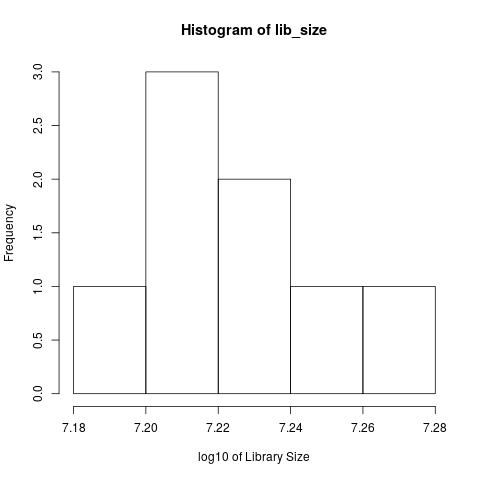

```python
%%R

#reformat count_data
count_gene<-count_data[-c(1:5),-1]
row.names(count_gene)<-count_data[-c(1:5),1]

lib_size<-log10(colSums(count_gene))

hist(lib_size, xlab="log10 of Library Size")
```

## A. Using EdgeR:

```python
%%R

#load packages
require(edgeR, warn.conflicts = F, quietly = T)

lib_names<-names(count_gene)

#load metadata information about the experiment and assign row names based on library name
#this will allow for us to quickly reference things by library
metadata<-read.table("RNAseq_metadata.txt",sep="\t", header=TRUE, row.names=1)

print(metadata)

#build the statistical model
design <- model.matrix(~ metadata[lib_names,"condition"])

#create EdgeR object
y <- DGEList(counts = count_gene[,lib_names],
             group = metadata[lib_names,"condition"],
             remove.zeros = TRUE )
```

```
R[write to console]: Removing 5712 rows with all zero counts
```

```
                        fileName condition
SRR1964648_1 SRR1964648_1.counts      LF1A
SRR1964649_1 SRR1964649_1.counts      LF1A
SRR1964646_1 SRR1964646_1.counts      LA2A
SRR1964647_1 SRR1964647_1.counts      LA2A
SRR1964642_1 SRR1964642_1.counts      LB2A
SRR1964643_1 SRR1964643_1.counts      LB2A
SRR1964644_1 SRR1964644_1.counts      LC2A
SRR1964645_1 SRR1964645_1.counts      LC2A
```

When we are loading the count data and the conditions associated with the experiment, it is essential that columns and rows match up. To do this we use the `lib_name` in the square bracket to re-order the count_gene and metadata objects when we construct the inputs for edgeR.

## B. Normalization:

edgeR is concerned with differential expression analysis rather than with the quantification of expression levels. It is concerned with relative changes in expression levels between conditions, but not directly with estimating absolute expression levels. This greatly simplifies the technical influences that need to be taken into account, because any technical factor that is unrelated to the experimental conditions should cancel out of any differential expression analysis. For example, read counts can generally be expected to be proportional to length as well as to expression for any transcript, but edgeR does not generally need to adjust for gene length because gene length has the same relative influence on the read counts for each RNA sample. For this reason, normalization issues arise only to the extent that technical factors have sample-specific effects.

### Sequencing Depth

The most obvious technical factor that affects the read counts, other than gene expression levels, is the sequencing depth of each RNA sample. edgeR adjusts any differential expression analysis for varying sequencing depths as represented by differing library sizes. This is part of the basic modeling procedure and flows automatically into fold-change or p-value calculations. It is always present, and doesn’t require any user intervention.

### RNA composition

The second most important technical influence on differential expression is one that is less obvious. RNA-seq provides a measure of the relative abundance of each gene in each RNA sample, but does not provide any measure of the total RNA output on a per-cell basis. This commonly becomes important when a small number of genes are very highly expressed in one sample, but not in another. The highly expressed genes can consume a substantial proportion of the total library size, causing the remaining genes to be under-sampled in that sample. Unless this RNA composition effect is adjusted for, the remaining genes may falsely appear to be down-regulated in that sample [32]. The calcNormFactors function normalizes for RNA composition by finding a set of scaling factors for the library sizes that minimize the log-fold changes between the samples for most genes. The default method for computing these scale factors uses a trimmed mean of M- values (TMM) between each pair of samples [32]. We call the product of the original library size and the scaling factor the effective library size. The effective library size replaces the original library size in all downsteam analyses. TMM is the recommended for most RNA-Seq data where the majority (more than half) of the genes are believed not differentially expressed between any pair of the samples. The following commands perform the TMM normalization and display the normalization factors.

```python
%%R

#normalize the counts
y <-calcNormFactors(y,method="TMM")

print(y$samples)
```

```
             group lib.size norm.factors
SRR1964642_1  LB2A 16728656    1.0203476
SRR1964643_1  LB2A 16310120    1.0219279
SRR1964644_1  LC2A 16589180    0.9458618
SRR1964645_1  LC2A 16738975    0.9509216
SRR1964646_1  LA2A 15936634    1.1206806
SRR1964647_1  LA2A 15622082    1.1203915
SRR1964648_1  LF1A 18322205    0.9190539
SRR1964649_1  LF1A 17513558    0.9239885
```

### Biological coefficient of variation (BCV)

Biological coefficient of variation is the coefficient of variation with which the (unknown) true abundance of the gene varies between replicate RNA samples. It represents the coefficient of variation (CV) that would remain between biological replicates if sequencing depth could be increased indefinitely. The technical CV decreases as the size of the counts increases. BCV on the other hand does not. BCV is therefore likely to be the dominant source of uncertainty for high-count genes, so reliable estimation of BCV is crucial for realistic assessment of differential expression in RNA-Seq experiments. If the abundance of each gene varies between replicate RNA samples in such a way that the genewise standard deviations are proportional to the genewise means, a commonly occurring property of measurements on physical quantities, then it is reasonable to suppose that BCV is approximately constant across genes. We allow however for the possibility that BCV might vary between genes and might also show a systematic trend with respect to gene expression or expected count.  
The magnitude of BCV is more important than the exact probabilistic law followed by the true gene abundances. For mathematical convenience, we assume that the true gene abundances follow a gamma distributional law between replicate RNA samples. This implies that the read counts follow a negative binomial probability law.  
The parallel nature of sequencing data allows some possibilities for borrowing information from the ensemble of genes which can assist in inference about each gene individually. The easiest way to share information between genes is to assume that all genes have the same mean-variance relationship, in other words, the dispersion is the same for all the genes. An extension to this “common dispersion” approach is to put a mean-dependent trend on a parameter in the variance function, so that all genes with the same expected count have the same variance.  
However, the truth is that the gene expression levels have non-identical and dependent distribution between genes, which makes the above assumptions too naive. A more general approach that allows genewise variance functions with empirical Bayes moderation was in- troduced several years ago and was extended to generalized linear models and thus more complex experimental designs. Only when using tagwise dispersion will genes that are consistent between replicates be ranked more highly than genes that are not. It has been seen in many RNA-Seq datasets that allowing gene-specific dispersion is necessary in order that differential expression is not driven by outliers. Therefore, the tagwise dispersions are strongly recommended in model fitting and testing for differential expression.

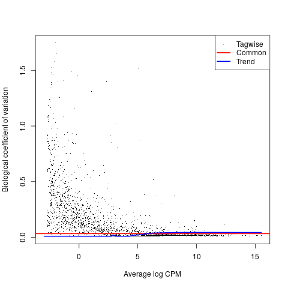

```python
%%R

#estimate dispersion parameters
y <-estimateDisp(y,design)

plotBCV(y)
```

## C. Comparision between groups:

### Pairwise comparisons between two groups

For all the Next-Gen squencing data analyses we consider here, people are most interested in finding differentially expressed genes/tags between two groups. Once negative binomial models are fitted and dispersion estimates are obtained, we can proceed with testing procedures for determining differential expression using the exact test. Knowing the conditional distribution for the sum of counts in a group, we can compute exact p-values by summing over all sums of counts that have a probability less than the probability under the null hypothesis of the observed sum of counts. The exact test for the negative binomial distribution has strong parallels with Fisher’s exact test and students t-test.

```python
%%R

#compare the expression between two groups
#FC would be: in comparison to LB2A, how much did LA2A change
et <- exactTest(y, pair=c("LB2A","LA2A"))

print(topTags(et))

summary(de <- decideTestsDGE(et))
```

```
Comparison of groups:  LA2A-LB2A
                     logFC   logCPM PValue FDR
GeneID:104926391  7.586340 5.933987      0   0
GeneID:104928771  6.807888 4.950548      0   0
GeneID:104933695  6.499897 6.811360      0   0
GeneID:109140403  6.286977 6.272070      0   0
GeneID:104922455  5.651180 6.104874      0   0
GeneID:104934661 -5.387295 6.411142      0   0
GeneID:104928555  5.287449 8.369240      0   0
GeneID:104924692  5.237711 6.342894      0   0
GeneID:104930671  4.878314 4.762571      0   0
GeneID:104931795  4.834677 5.243110      0   0
       LA2A-LB2A
Down        5476
NotSig     10568
Up          5483
```

### More complex experiments (glm)

Generalized linear models (GLMs) are an extension of classical linear models to nonnormally distributed response data. GLMs specify probability distributions according to their mean-variance relationship, for example the quadratic mean-variance relationship specified above for read counts. For general experiments, once dispersion estimates are obtained and negative binomial generalized linear models are fitted, we can proceed with testing procedures for determining differential expression using either quasi-likelihood (QL) F-test or likelihood ratio test.

In our experiment, we consider the four treatment groups, each with two replicates, and the researcher wants to make pairwise comparisons between them. A QL model representing the study design can be fitted to the data with commands such as:

```python
%%R

#determined from design matrix
#LA2A = 1 (intercept)
#LB2A = 2 (control)
#LC2A = 3
#LF1A = 4

fit <- glmQLFit(y, design)

#in comparison to LA2A (1) how much did LB2A (2) change:
qlf.2vs1 <- glmQLFTest(fit, coef=2)
topTags(qlf.2vs1)
```

```
Coefficient:  metadata[lib_names, "condition"]LB2A
                     logFC    logCPM         F       PValue          FDR
GeneID:104929331 -4.662615 10.507850 515409.30 7.989044e-15 1.719802e-10
GeneID:104938146 -2.713635 11.248578 178585.52 1.452264e-13 1.563145e-09
GeneID:104935382 -2.923986  9.459917 120439.21 4.267421e-13 2.209608e-09
GeneID:104926156 -3.267658  8.336306 118812.58 4.429191e-13 2.209608e-09
GeneID:104925216 -3.512231  6.115416 104294.17 6.327081e-13 2.209608e-09
GeneID:104940059 -3.219008 10.234265  99491.48 7.198231e-13 2.209608e-09
GeneID:104928555 -5.287403  8.369240  95649.66 8.017193e-13 2.209608e-09
GeneID:104940315  2.985962  9.589646  91076.81 9.167217e-13 2.209608e-09
GeneID:104926919 -2.958653  8.363649  88010.16 1.006790e-12 2.209608e-09
GeneID:104923865 -2.579144  8.103076  87390.76 1.026436e-12 2.209608e-09
```

```python
%%R
#in comparison to LB2A (2) how much did LC2A (3) change:
qlf.3vs2 <- glmQLFTest(fit, contrast=c(0,-1,1,0))

topTags(qlf.3vs2)
```

```
Coefficient:  -1*metadata[lib_names, "condition"]LB2A 1*metadata[lib_names, "condition"]LC2A
                     logFC    logCPM         F       PValue          FDR
GeneID:104933461 -4.746763  8.562723 196224.37 1.122308e-13 2.415993e-09
GeneID:104929331  2.145491 10.507850 130903.15 3.397512e-13 2.757067e-09
GeneID:104928555  5.862203  8.369240 115669.56 4.766326e-13 2.757067e-09
GeneID:104925605  5.565889  8.801819  91955.20 8.929591e-13 2.757067e-09
GeneID:104929232  2.900187  8.075037  88105.59 1.003809e-12 2.757067e-09
GeneID:109136649  6.391099  6.162314  87194.54 1.032769e-12 2.757067e-09
GeneID:104939928 -4.155949  7.079037  82857.22 1.187503e-12 2.757067e-09
GeneID:104932538  2.480165  8.499745  78497.45 1.376788e-12 2.757067e-09
GeneID:104921782  2.894438  6.500516  78257.04 1.388392e-12 2.757067e-09
GeneID:104927028 -3.307354  6.902796  76946.89 1.454035e-12 2.757067e-09
```

```python
%%R

#To find genes different between any of the four groups:
qlf <- glmQLFTest(fit, coef=2:4)
topTags(qlf)
```

```
Coefficient:  metadata[lib_names, "condition"]LB2A metadata[lib_names, "condition"]LC2A metadata[lib_names, "condition"]LF1A
                 logFC.metadata.lib_names...condition..LB2A
GeneID:104931936                                  2.9113275
GeneID:104940476                                  1.6891359
GeneID:104929331                                 -4.6626153
GeneID:104940626                                  1.3671129
GeneID:104933461                                  1.1105738
GeneID:104918527                                 -0.7181912
GeneID:104930094                                  0.8189547
GeneID:104931901                                 -2.6571446
GeneID:104922235                                  1.3931366
GeneID:104936356                                 -0.6135350
                 logFC.metadata.lib_names...condition..LC2A
GeneID:104931936                                  1.0655905
GeneID:104940476                                  3.8903596
GeneID:104929331                                 -2.5171238
GeneID:104940626                                  3.0095840
GeneID:104933461                                 -3.6361889
GeneID:104918527                                  1.2290692
GeneID:104930094                                  1.5653284
GeneID:104931901                                 -3.2075621
GeneID:104922235                                  1.0381296
GeneID:104936356                                  0.4578227
                 logFC.metadata.lib_names...condition..LF1A    logCPM        F
GeneID:104931936                                  16.802471 10.837218 909608.5
GeneID:104940476                                   8.915673 10.468004 529463.3
GeneID:104929331                                  -5.566642 10.507850 364597.8
GeneID:104940626                                  -1.198524 12.214626 165007.4
GeneID:104933461                                  -5.070116  8.562723 137299.5
GeneID:104918527                                   3.394101 11.270728 115453.8
GeneID:104930094                                  -2.560272 10.829675 112684.3
GeneID:104931901                                   5.097795  8.035376 110657.3
GeneID:104922235                                  -2.601616 14.164948 108573.7
GeneID:104936356                                   3.024494  9.351297 108553.9
                       PValue          FDR
GeneID:104931936 5.406763e-16 1.163914e-11
GeneID:104940476 2.377034e-15 2.558521e-11
GeneID:104929331 6.597605e-15 4.734221e-11
GeneID:104940626 5.774867e-14 3.107889e-10
GeneID:104933461 9.549840e-14 3.909762e-10
GeneID:104918527 1.534388e-13 3.909762e-10
GeneID:104930094 1.639794e-13 3.909762e-10
GeneID:104931901 1.723298e-13 3.909762e-10
GeneID:104922235 1.815305e-13 3.909762e-10
GeneID:104936356 1.816213e-13 3.909762e-10
```

Often it is important to capture all the DE genes and write them to a table. To do this we can modify the options in the `decideTestsDGE` function to give us all the genes.

```python
%%R

#get the number of DE genes and store the results in lrt$table
de.qlf <- decideTestsDGE(qlf)
qlf$table[,5]<-de.qlf
names(qlf$table)[5]<-"Decide_test"

write.table(qlf$table,file="DE_genes.csv", sep=",", quote=F)
```

## D. Common plots for differential expression analysis:

**Bland-Altman (smear) Plot**

```
M = log2(D1/D2) = log2(D1)-log2(D2)
A = ½log2(D1D2) = ½(log2(D1)+log2(D2))
```

with D1 and D2 being datasets 1 and 2, respectively. We plot M on the vertical axis and A on the horizontal axis. We see here that should two datapoints from datasets 1 and 2 be equal, they will plot at (D1==D2, 0). Therefore, should our entire plot run along y=0, it is safe to say, that for us, none of our genes were differentially expressed. However, should there be large deviations from y=0, we are provided with insight that we may have differentially expressed genes.

**Heatmap**

Heatmaps are the most readily readable visualizations for determining differential expression. Heatmaps are discrete plots. That is, the values along the x and y axis move in integer increments, with no places in-between. Typically, the x-and-y axes contain different types of information about each dataset, and combine to capture the whole image of the dataset. For us, we may find it useful to make one axis our groups (our four datasets) and the other axis the genes sampled from those datasets. Now each cell in our grid will correspond to the expression of a gene from a sample. We then assign a color-palette to each possible range of gene expression. For instance, an expression between 300-500 may be blue while an expression of 501-1000 may be violet. After coloring all of our cells responsibly, we now have simple, discrete snapshots of each datasets expression distribution. Should we notice that two groups have very similar looking snapshots, we may cluster those groups safely with the assumption that they do not share differentially expressed genes, and therefore belong to the same space.

**Multidimensional scaling (MDS)**

Multidimensional scaling (MDS) is a technique used to emphasize variation and bring out strong patterns in a dataset. It's often used to make data easy to explore and visualize. It is a mathematical procedure that transforms a number of corrlated variables into similarity distances that approximate the expression differences between the samples. Typically these are plotted in two-dimensional scatterplots but realized that these can be complex multi-dimensional plots.

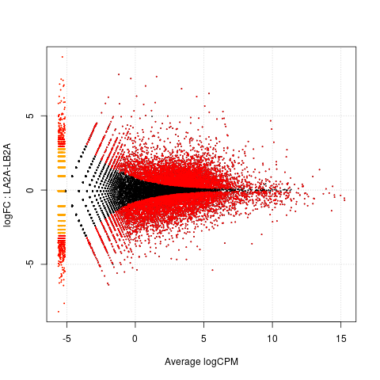

```python
%%R

#plot Bland-Altman(smear) Plot
detags <- rownames(y)[as.logical(decideTestsDGE(exactTest(y, pair=c("LB2A","LA2A"))))]
plotSmear(y,pair=c("LB2A","LA2A"), de.tags=detags)
```

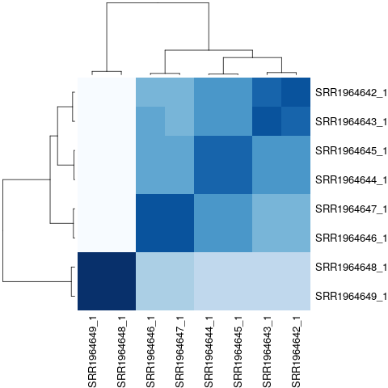

```python
%%R
require("RColorBrewer", quiet=T)

#plot heatmap of samples

#convert counts to euclidean distances
sampleDists <- as.matrix(dist(t(count_gene)))


cimColor <- colorRampPalette(rev(brewer.pal(9, "Blues")))(16)
heatmap(sampleDists, col=cimColor, margin = c(8,8))
```

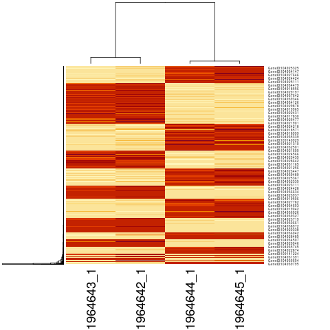

```python
%%R

#create heatmap with a subset of DE genes
detags <- rownames(y)[as.logical(decideTestsDGE(exactTest(y, pair=c("LB2A","LC2A"))))]

#plot heatmap of samples and genes
heatmap(as.matrix(count_gene[detags,c("SRR1964642_1", "SRR1964643_1", "SRR1964644_1", "SRR1964645_1")]), margin = c(8,8))
```

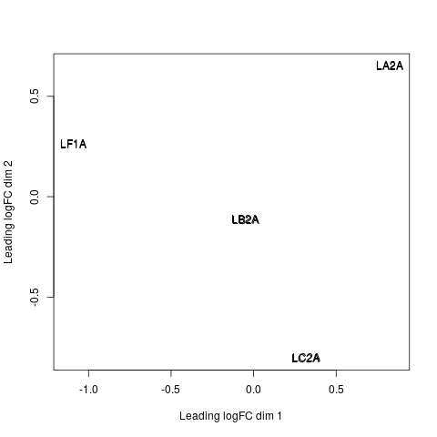

```python
%%R

##compare libraries by plots MDS ordnation of samples
plotMDS(y,top=10000, labels=metadata[lib_names,"condition"])
```

# 7. Integrating the DE Results with the Annotation Results

Once the differentially expressed genes have been identified, we need to annotate the genes to identify the function. To do this we will be merging the DE gene list from above with the funtional annotation of the gene features. First lets look at the structure of the two tables.

```python
%%R

DE_genes<-read.csv("DE_genes.csv")

print("DE gene table")
print(head(DE_genes, n=3))

annotat<-read.csv("ProteinTable12197_229515.txt", sep="\t", header=T)


print("Gene annotation table")
print(head(annotat, n=3))
```

```
[1] "DE gene table"
                 logFC.metadata.lib_names...condition..LB2A
GeneID:104917625                                  0.1925568
GeneID:104917626                                 -0.4717997
GeneID:104917627                                 -3.6258488
                 logFC.metadata.lib_names...condition..LC2A
GeneID:104917625                                 -0.1922151
GeneID:104917626                                  0.8122524
GeneID:104917627                                 -3.6258488
                 logFC.metadata.lib_names...condition..LF1A     logCPM
GeneID:104917625                                 -3.6030595  0.4125387
GeneID:104917626                                  0.4890006 -0.3764740
GeneID:104917627                                 -0.4400520 -2.6708856
                 Decide_test     PValue
GeneID:104917625           0 0.24524629
GeneID:104917626           0 0.15144076
GeneID:104917627           0 0.07698883
[1] "Gene annotation table"
  X.Replicon.Name Replicon.Accession Start Stop Strand    GeneID        Locus
1              Un     NW_017607850.1    71 6306      + 109136730 LOC109136730
2              Un     NW_017607851.1  1839 5198      - 104920847 LOC104920847
3              Un     NW_017607853.1     7  656      - 109141431 LOC109141431
  Protein.product Length
1  XP_019114579.1    552
2  XP_019122094.1    153
3  XP_019129876.1    217
                                               Protein.name
1 PREDICTED: MORC family CW-type zinc finger protein 3-like
2      PREDICTED: UBX domain-containing protein 2A, partial
3  PREDICTED: uncharacterized protein K02A2.6-like, partial
```

```python
%%R

row.names(DE_genes)<-sub("GeneID\\:(\\d+)", "\\1", row.names(DE_genes), perl=TRUE )

head(DE_genes)
```

```
          logFC.metadata.lib_names...condition..LB2A
104917625                                 0.19255682
104917626                                -0.47179971
104917627                                -3.62584875
104917628                                -0.06532926
104917629                                -1.23620599
104917630                                 2.16673036
          logFC.metadata.lib_names...condition..LC2A
104917625                                 -0.1922151
104917626                                  0.8122524
104917627                                 -3.6258488
104917628                                  0.3822346
104917629                                 -1.3609742
104917630                                 -1.6374119
          logFC.metadata.lib_names...condition..LF1A     logCPM Decide_test
104917625                                 -3.6030595  0.4125387           0
104917626                                  0.4890006 -0.3764740           0
104917627                                 -0.4400520 -2.6708856           0
104917628                                 -0.4939666  3.6424151           1
104917629                                 -1.9957017  2.4123756           1
104917630                                  3.0016780  0.2767365           1
                PValue
104917625 2.452463e-01
104917626 1.514408e-01
104917627 7.698883e-02
104917628 2.118637e-06
104917629 2.498882e-07
104917630 8.077861e-06
```

In addition, we need to remove duplicate genes from the annotation file because it contains isoform information which we are not using in this analysis.

```python
%%R

#this will return boolean (TRUE or FALSE) if name is a duplicate
index<-duplicated(annotat[,"GeneID"])

#remove duplicated gene names
annotat<-annotat[!index,]

head(annotat)
```

```
  X.Replicon.Name Replicon.Accession Start  Stop Strand    GeneID        Locus
1              Un     NW_017607850.1    71  6306      + 109136730 LOC109136730
2              Un     NW_017607851.1  1839  5198      - 104920847 LOC104920847
3              Un     NW_017607853.1     7   656      - 109141431 LOC109141431
4              Un     NW_017607862.1 32281 34802      + 109137990 LOC109137990
5              Un     NW_017607863.1 14251 16230      + 109138189 LOC109138189
6              Un     NW_017607869.1   466  8284      + 104939476 LOC104939476
  Protein.product Length
1  XP_019114579.1    552
2  XP_019122094.1    153
3  XP_019129876.1    217
4  XP_019112777.1    434
5  XP_019113565.1    188
6  XP_019117313.1    520
                                               Protein.name
1 PREDICTED: MORC family CW-type zinc finger protein 3-like
2      PREDICTED: UBX domain-containing protein 2A, partial
3  PREDICTED: uncharacterized protein K02A2.6-like, partial
4            PREDICTED: zinc finger MYM-type protein 1-like
5        PREDICTED: unconventional myosin-XIX-like, partial
6                         PREDICTED: BCL-6 corepressor-like
```

Lastly, we `merge` the two data frames based on the GeneIDs by specifying the `by.x` column that should be matched to the `by.y` column. The most interesting column in this larger data frmae is the Protein.name because it gives a description of the protein.

```python
%%R

DE_annotat<- merge(DE_genes, annotat, by.x="row.names", by.y="GeneID", all.x=T)

write.table(DE_annotat, file="DE_genes_annotation.txt", sep="\t", quote=F, row.names=F)

head(DE_annotat)
```

```
  Row.names logFC.metadata.lib_names...condition..LB2A
1 104917625                                 0.19255682
2 104917626                                -0.47179971
3 104917627                                -3.62584875
4 104917628                                -0.06532926
5 104917629                                -1.23620599
6 104917630                                 2.16673036
  logFC.metadata.lib_names...condition..LC2A
1                                 -0.1922151
2                                  0.8122524
3                                 -3.6258488
4                                  0.3822346
5                                 -1.3609742
6                                 -1.6374119
  logFC.metadata.lib_names...condition..LF1A     logCPM Decide_test
```

[output cut: 27 more lines]